# Temporality and disruption of routines

March 27, 2019

## 1. Temporality literature

Identified as import issue in many research streams:

- Temporality and sustainability (Bansal & DesJardine 2014)
- Agent's temporal orientation (Wowak et al. 2015)
- Decision speed (Kwnatzki et al. 2013)

## 2. Researching "pace"

- At what pace (frequency) are changes made?
- Is a company moving slow or moving fast?
- A focus on the content of decisions can obscure the issue of how decisions are received.

**For instance, a company that changes a policy 5x in one year could only be sure that there is confusion and volatility.**

## 3. Why it matters

- Often focus in literature on the regular, steady processes
- E.g, exclusion of crisis years, "abnormal" industries from modeling
- Irregular events can have unequally big effect on outcome measure
  - E.g., performance (insert your own example)
  - In sustainability: environmental impacts of disasters
  - E.g., deepwater horizont oil spill
    - Spilling a couple of barrels every now and then during regular operations
    - 4.9 million barrels in one event
- Prevent disasters, rather than optimizing regular operations

## 4. Modeling approaches (in theory)

Internal vs. external perspective

- Internal
  - Impression management
  - Intention vs effects "on the ground"
- External
  - Challenge: lack of introspective

## 4. Modeling approaches: data

- M&As
- **Turnover**
  - Cause of changes (leadership change)
  - Symptom of changes (layoffs)
- Media perspective (external)

## 4. Modeling approaches: the challenge

- Model change as a cumulative phenomenon
- How do we conceptualize instability as a quantitative phenomenon?

## 5. Outcome variables

- Industrial disasters
- **Product recalls**
- Conventional performance measures

## 6. Data: sample

```r
sample <- read_feather('../sample 2019-03-16.feather')
unique(sample$name)
```

```
##  [1] "Best Buy Co Inc"            "Officemax Inc"
##  [3] "Circuit City Stores Inc"    "Target Corp"
##  [5] "Dillards Inc  -Cl A"        "Dollar General Corp"
##  [7] "Family Dollar Stores"       "Macy'S Inc"
##  [9] "Gap Inc"                    "Genuine Parts Co"
## [11] "Home Depot Inc"             "Sears Holdings Corp"
## [13] "L Brands Inc"               "Lowe'S Companies Inc"
## [15] "May Department Stores Co"   "Nordstrom Inc"
## [17] "Penney (J C) Co"            "Pep Boys-Manny Moe & Jack"
## [19] "Autonation Inc"             "Ross Stores Inc"
## [21] "Sears Roebuck & Co"         "Rs Legacy Corp"
## [23] "Toys R Us Inc"              "Foot Locker Inc"
## [25] "Tjx Companies Inc"          "Big Lots Inc"
## [27] "Tiffany & Co"               "Office Depot Inc"
## [29] "Signet Jewelers Ltd"        "Staples Inc"
## [31] "Autozone Inc"               "Kohl'S Corp"
## [33] "Bed Bath & Beyond Inc"      "O'Reilly Automotive Inc"
## [35] "Petsmart Inc"               "Urban Outfitters Inc"
## [37] "Tractor Supply Co"          "Dollar Tree Inc"
## [39] "Abercrombie & Fitch  -Cl A" "Carmax Inc"
## [41] "Gamestop Corp"              "Advance Auto Parts Inc"
## [43] "Lkq Corp"                   "Ulta Beauty Inc"
```

## 6. Data: recalls

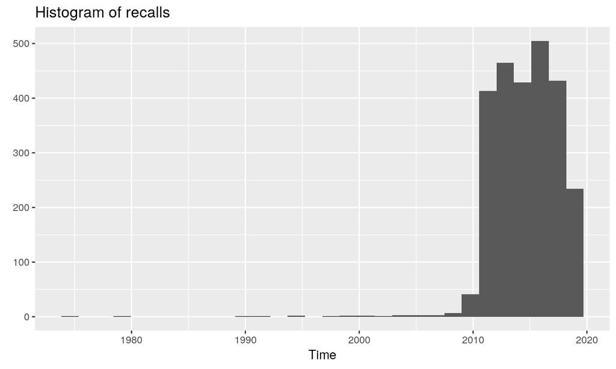

```r
cpsc <- read_csv("../downloads/cpsc.csv")
cpsc$date <- mdy(cpsc$date)
cpsc %>%
  ggplot(aes(x=date)) + geom_histogram() + labs(title = "Histogram of recalls", x="Time", y=element_blank())
```

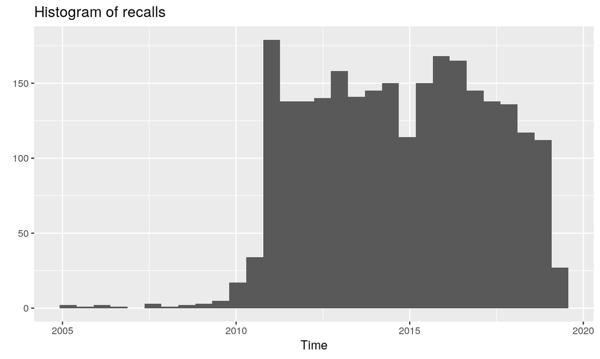

```r
cpsc %>%
  filter(.$date >= date("2005-01-01")) %>%
  ggplot(aes(x=date)) + geom_histogram() +
  labs(title = "Histogram of recalls", x="Time", y=element_blank())
```

## 6. Data: turnover I

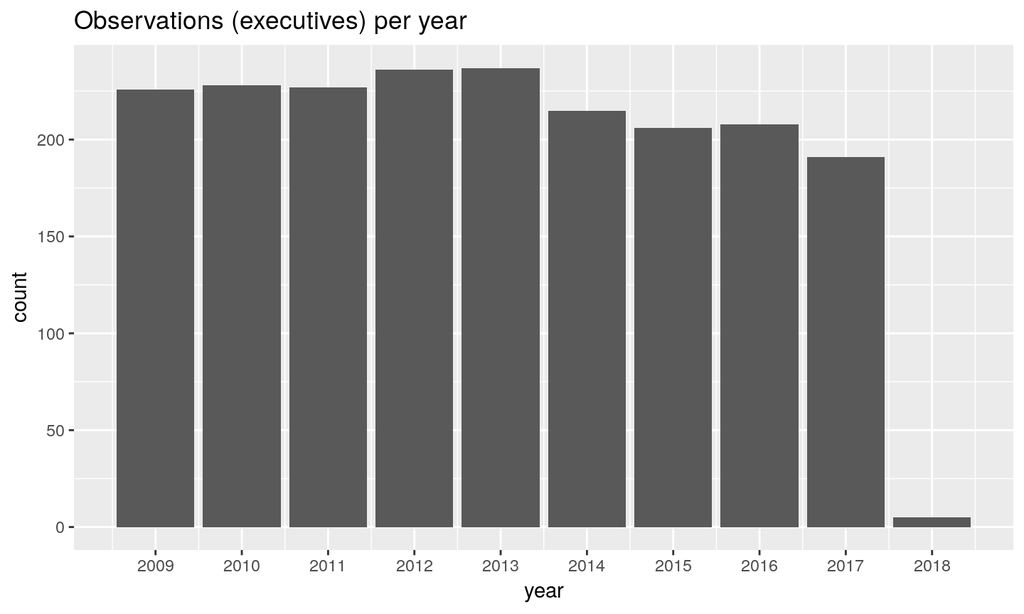

```r
sample %>%
  ggplot(aes(x = year)) + geom_bar() + labs(title = 'Observations (executives) per year') +
  scale_x_continuous(breaks = seq(2009, 2018, by = 1))
```

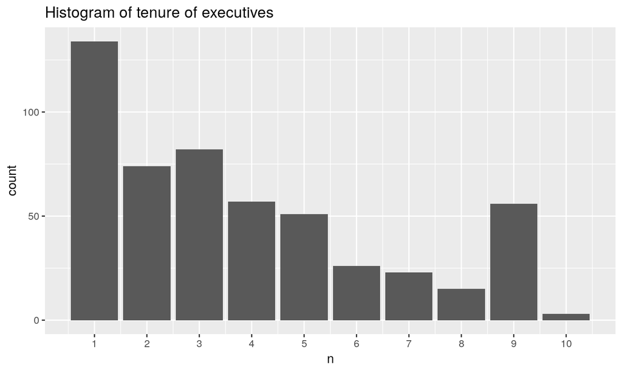

```r
sample %>% group_by(execid) %>% summarize(n = n()) %>%
  ggplot(aes(x=n)) + geom_bar() + labs(title='Histogram of tenure of executives') +
  scale_x_continuous(breaks = seq(0, 10, by=1))
```

## References

- Bansal, P., & DesJardine, M. (2014). Business sustainability: It is about time. Strategic Organization, 12(1), 70–78. https://doi.org/10.1177/1476127013520265
- Kownatzki, M., Walter, J., Floyd, S. W., & Lechner, C. (2013). Corporate Control and the Speed of Strategic Business Unit Decision Making. Academy of Management Journal, 56(5), 1295–1324. https://doi.org/10.5465/amj.2011.0804
- Wowak, A. J., Mannor, M. J., & Wowak, K. D. (2015). Throwing Caution to the Wind: The Effect of CEO Stock Option Pay on the Incidence of Product Safety Problems. Strategic Management Journal, 36(7), 1082–1092. https://doi.org/10.1002/smj.2277